# Machine Learning Project

Harold Trammel

October 10, 2015

## Question

In 2013, Velloso *et al* presented a paper describing their approach to qualitatively recognizing activity through the use of sensors. Their Weight Lifting Exercises (WLE) dataset has been provided.

I was presented the following questions:

- Can a machine learning approach using the WLE dataset accurately identify when a user has correctly performed a weight lifting exercise?
- If they did not, identify how their exercise was incorrect?

## Input data

Velloso, *et al* described the WLE dataset as follows:

“Six young health participants were asked to perform one set of 10 repetitions of the Unilateral Dumbbell Biceps Curl in five different fashions: exactly according to the specification (Class A), throwing the elbows to the front (Class B), lifting the dumbbell only halfway (Class C), lowering the dumbbell only halfway (Class D) and throwing the hips to the front (Class E). Class A corresponds to the specified execution of the exercise, while the other 4 classes correspond to common mistakes. …” in: Velloso, E.; Bulling, A.; Gellersen, H.; Ugulino, W.; Fuks, H. Qualitative Activity Recognition of Weight Lifting Exercises. Proceedings of 4th International Conference in Cooperation with SIGCHI (Augmented Human ’13) . Stuttgart, Germany: ACM SIGCHI, 2013.

I was provided a training set and a testing set of data from the WLE dataset.

### Data Exploration

The training dataset had 19622 observations with 160 variables. The testing set had the same number of variables but only twentry observations. I chose to partition the training dataset with 70% for training and 30% for validation.

Because of the large number of variables, I used a random forest approach. Many of the variables had null or NA values. Because the random forest methodology does not handle NA or null values, these variables were removed: variables beginning with “kurtosis_”, “skewness_”, “amplitude_”, “avg_”, “min_”, “max_”, “var_”, or “stddev_”. This removed 100 variables.

## Features

I created a preliminary random forest with the *classe* variable as the outcome and all other variables as predictors. This was used in the varImpPlot function to obtain a starting point for feature selection. Based the intial run, I removed the following variables: “X”, “new_window”, “cvtd_timestamp”, “raw_timestamp_part_1”, “raw_timestamp_part_2”, and “num_window”. After removing these variables, I created a new random forest with the same parameters. The output of the varImpPlot for this forest is shown below.

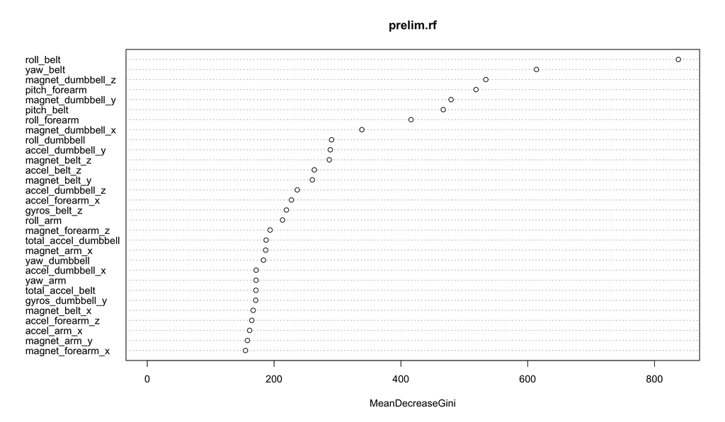

Based on this, I incrementally added the following predictors until the OOB estimate of error rate appeared to bottom out.

## Algorithm

I used the randomForest package instead of the caret rf() function.

```
##
## Call:
##  randomForest(formula = classe ~ roll_belt + yaw_belt + magnet_dumbbell_z +      pitch_forearm + magnet_dumbbell_y + pitch_belt + roll_forearm,      data = train_df, mdim2nd = 15, keep.forest = TRUE)
##                Type of random forest: classification
##                      Number of trees: 500
## No. of variables tried at each split: 2
##
##         OOB estimate of  error rate: 1.5%
## Confusion matrix:
##      A    B    C    D    E class.error
## A 3864   20   19    3    0      0.0108
## B   26 2579   40   12    1      0.0297
## C    2   18 2362   14    0      0.0142
## D    0    5   10 2232    5      0.0089
## E    0   16    7    6 2496      0.0115
```

## Parameters

I used the following parameters:

- mdim2nd=15, which provides an automatic 2nd run using the k most important variables from the first run.
- keep.forest=TRUE, which means the forest will be retained after the run

## Evaluation

I used the validation data partition for my evaluation.

The caret *confusionMatrix* function with the validation data frame as the test component produced the following results:

```
## Confusion Matrix and Statistics
##
##           Reference
## Prediction    A    B    C    D    E
##          A 1655    6    5    0    0
##          B    7 1102    9    1    9
##          C    9   25 1007   17    3
##          D    3    6    5  946    1
##          E    0    0    0    0 1069
##
## Overall Statistics
##
##                Accuracy : 0.982
##                  95% CI : (0.978, 0.985)
##     No Information Rate : 0.284
##     P-Value [Acc > NIR] : <2e-16
##
##                   Kappa : 0.977
##  Mcnemar's Test P-Value : NA
##
## Statistics by Class:
##
##                      Class: A Class: B Class: C Class: D Class: E
## Sensitivity             0.989    0.968    0.981    0.981    0.988
## Specificity             0.997    0.995    0.989    0.997    1.000
## Pos Pred Value          0.993    0.977    0.949    0.984    1.000
## Neg Pred Value          0.995    0.992    0.996    0.996    0.997
## Prevalence              0.284    0.194    0.174    0.164    0.184
## Detection Rate          0.281    0.187    0.171    0.161    0.182
## Detection Prevalence    0.283    0.192    0.180    0.163    0.182
## Balanced Accuracy       0.993    0.981    0.985    0.989    0.994
```